# Experiment 1.5 Analysis

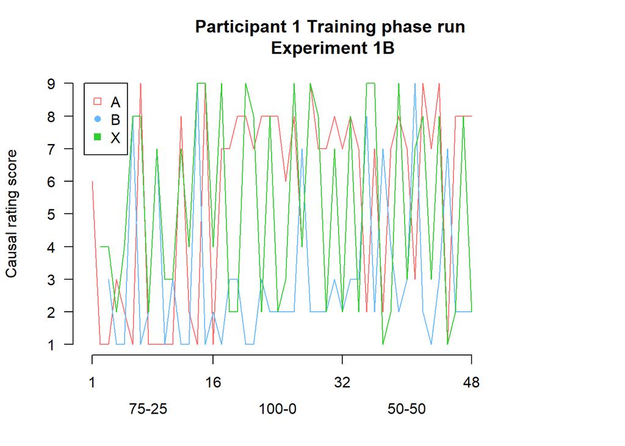

```r
#still P1
par(mfrow = c(1,1))
par(las = 1)
emptyPlot(c(1,60), c(1,9), xmark = c(1,16,32,48), ymark= c(1,2,3,4,5,6,7,8,9), bty = 'n', main = "Participant 1 Training phase run\n Experiment 1B", xlab = "", ylab = "Causal rating score")
points(c(1:48), P1$responseR1, type = 'l', col = "indianred1", lty = 1, lwd = 1)
points(c(1:48), P1$responseR2, type = 'l', col = "steelblue1", lty = 1, lwd = 1)
points(c(1:48), P1$responseR3, type = 'l', col = "limegreen", lty = 1, lwd = 1)
mtext("75-25", side = 1, at = 8, line = 2.5)
mtext("100-0", side = 1, at = 24, line = 2.5)
mtext("50-50", side = 1, at = 40, line = 2.5)
legend(0.02,9,legend =c("A", "B", "X"), pch = c(0,16,15), col = c("indianred1", "steelblue1", "limegreen"))
```

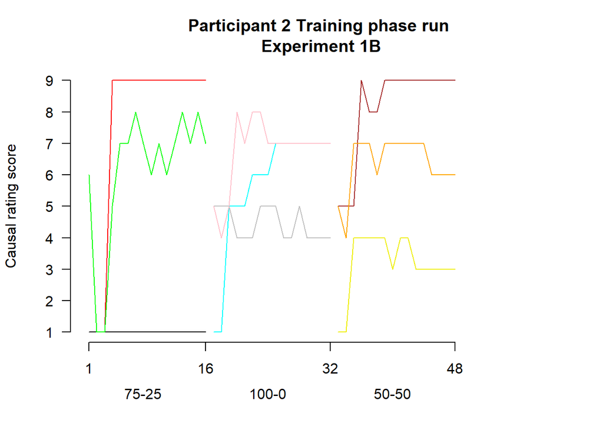

```r
#p2 had Cond 50, 100, 0.
par(mfrow = c(1,1))
par(las = 1)
emptyPlot(c(1,60), c(1,9), xmark = c(1,16,32,48), ymark= c(1,2,3,4,5,6,7,8,9), bty = 'n', main = "Participant 2 Training phase run\n Experiment 1B", xlab = "", ylab = "Causal rating score")
points(c(1:16), P2$responseR1[P2$blockNr == "Block1"], type = 'l', col = "red", lty = 1, lwd = 1)
points(c(1:16), P2$responseR2[P2$blockNr == "Block1"], type = 'l', col = "black", lty = 1, lwd = 1)
points(c(1:16), P2$responseR3[P2$blockNr == "Block1"], type = 'l', col = "green", lty = 1, lwd = 1)
points(c(17:32), P2$responseR1[P2$blockNr == "Block2"], type = 'l', col = "grey", lty = 1, lwd = 1)
points(c(17:32), P2$responseR2[P2$blockNr == "Block2"], type = 'l', col = "cyan", lty = 1, lwd = 1)
points(c(17:32), P2$responseR3[P2$blockNr == "Block2"], type = 'l', col = "pink", lty = 1, lwd = 1)
points(c(33:48), P2$responseR1[P2$blockNr == "Block3"], type = 'l', col = "brown", lty = 1, lwd = 1)
points(c(33:48), P2$responseR2[P2$blockNr == "Block3"], type = 'l', col = "yellow2", lty = 1, lwd = 1)
points(c(33:48), P2$responseR3[P2$blockNr == "Block3"], type = 'l', col = "orange", lty = 1, lwd = 1)
mtext("75-25", side = 1, at = 8, line = 2.5)
mtext("100-0", side = 1, at = 24, line = 2.5)
mtext("50-50", side = 1, at = 40, line = 2.5)
```

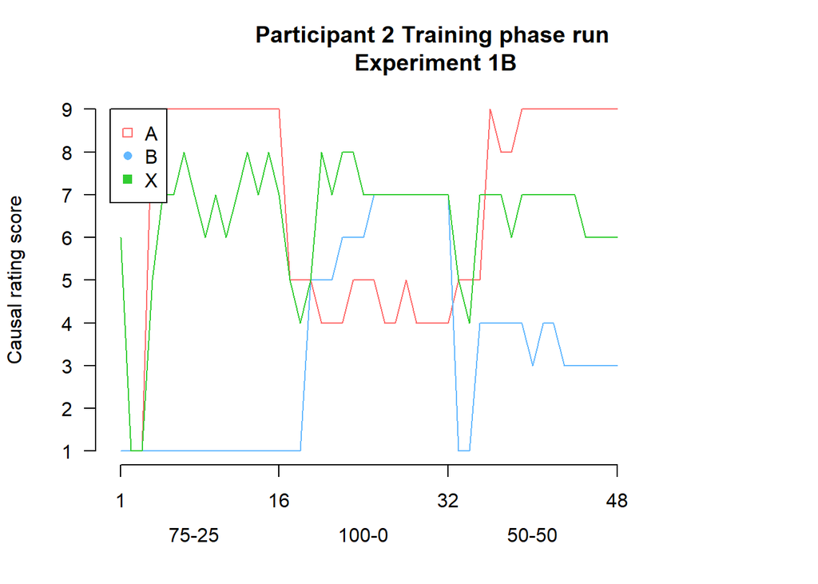

```r
#still P2
par(mfrow = c(1,1))
par(las = 1)
emptyPlot(c(1,60), c(1,9), xmark = c(1,16,32,48), ymark= c(1,2,3,4,5,6,7,8,9), bty = 'n', main = "Participant 2 Training phase run\n Experiment 1B", xlab = "", ylab = "Causal rating score")
points(c(1:48), P2$responseR1, type = 'l', col = "indianred1", lty = 1, lwd = 1)
points(c(1:48), P2$responseR2, type = 'l', col = "steelblue1", lty = 1, lwd = 1)
points(c(1:48), P2$responseR3, type = 'l', col = "limegreen", lty = 1, lwd = 1)
mtext("75-25", side = 1, at = 8, line = 2.5)
mtext("100-0", side = 1, at = 24, line = 2.5)
mtext("50-50", side = 1, at = 40, line = 2.5)
legend(0.02,9,legend =c("A", "B", "X"), pch = c(0,16,15), col = c("indianred1", "steelblue1", "limegreen"))
```

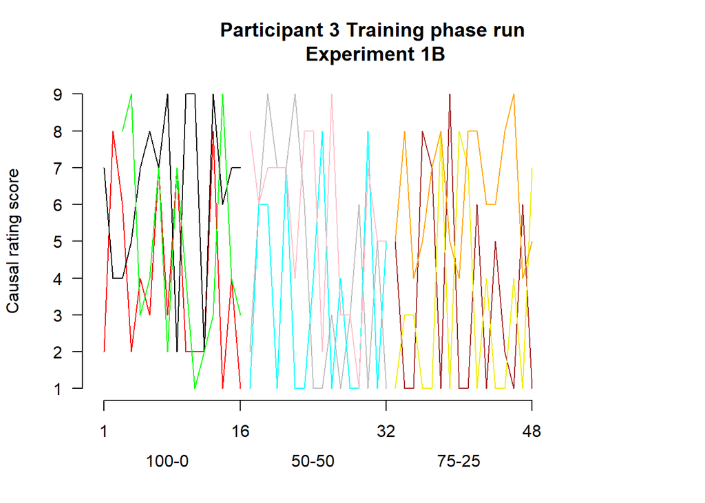

```r
#p3 had Cond 100, 0, 50.
par(mfrow = c(1,1))
par(las = 1)
emptyPlot(c(1,60), c(1,9), xmark = c(1,16,32,48), ymark= c(1,2,3,4,5,6,7,8,9), bty = 'n', main = "Participant 3 Training phase run\n Experiment 1B", xlab = "", ylab = "Causal rating score")
points(c(1:16), P3$responseR1[P3$blockNr == "Block1"], type = 'l', col = "red", lty = 1, lwd = 1)
points(c(1:16), P3$responseR2[P3$blockNr == "Block1"], type = 'l', col = "black", lty = 1, lwd = 1)
points(c(1:16), P3$responseR3[P3$blockNr == "Block1"], type = 'l', col = "green", lty = 1, lwd = 1)
points(c(17:32), P3$responseR1[P3$blockNr == "Block2"], type = 'l', col = "grey", lty = 1, lwd = 1)
points(c(17:32), P3$responseR2[P3$blockNr == "Block2"], type = 'l', col = "cyan", lty = 1, lwd = 1)
points(c(17:32), P3$responseR3[P3$blockNr == "Block2"], type = 'l', col = "pink", lty = 1, lwd = 1)
points(c(33:48), P3$responseR1[P3$blockNr == "Block3"], type = 'l', col = "brown", lty = 1, lwd = 1)
points(c(33:48), P3$responseR2[P3$blockNr == "Block3"], type = 'l', col = "yellow2", lty = 1, lwd = 1)
points(c(33:48), P3$responseR3[P3$blockNr == "Block3"], type = 'l', col = "orange", lty = 1, lwd = 1)
mtext("100-0", side = 1, at = 8, line = 2.5)
mtext("50-50", side = 1, at = 24, line = 2.5)
mtext("75-25", side = 1, at = 40, line = 2.5)
```

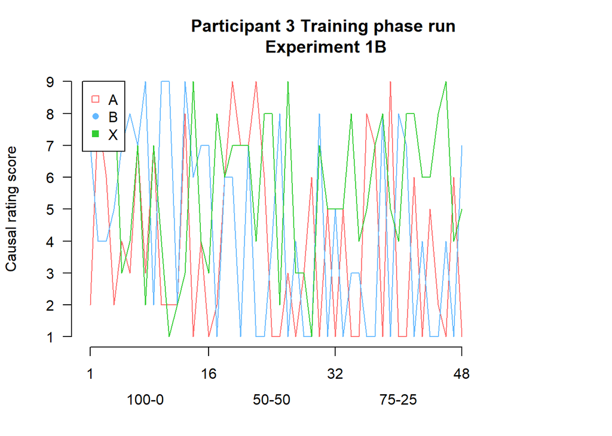

```r
#still P3
par(mfrow = c(1,1))
par(las = 1)
emptyPlot(c(1,60), c(1,9), xmark = c(1,16,32,48), ymark= c(1,2,3,4,5,6,7,8,9), bty = 'n', main = "Participant 3 Training phase run\n Experiment 1B", xlab = "", ylab = "Causal rating score")
points(c(1:48), P3$responseR1, type = 'l', col = "indianred1", lty = 1, lwd = 1)
points(c(1:48), P3$responseR2, type = 'l', col = "steelblue1", lty = 1, lwd = 1)
points(c(1:48), P3$responseR3, type = 'l', col = "limegreen", lty = 1, lwd = 1)
mtext("100-0", side = 1, at = 8, line = 2.5)
mtext("50-50", side = 1, at = 24, line = 2.5)
mtext("75-25", side = 1, at = 40, line = 2.5)
legend(0.02,9,legend =c("A", "B", "X"), pch = c(0,16,15), col = c("indianred1", "steelblue1", "limegreen"))
```

```r
#Calculating the average scores on the trials where "Diamond" was the outcome, and on trials where "No Diamond" was the outcome
#We would expect that the scores to the No Diamond would be lower on average
Diamond <- subset(train, train$Outcome == "Diamond.png")
NoDiamond <- subset(train, train$Outcome == "NoDiamond.png")

DiamondAvg <- aggregate(list(Diamond$responseR1, Diamond$responseR2, Diamond$responseR3), list(Diamond$Cond), mean, na.rm = T)
NoDiamondAvg <- aggregate(list(NoDiamond$responseR1, NoDiamond$responseR2, NoDiamond$responseR3), list(NoDiamond$Cond), mean, na.rm = T)
SE <- c(std.error(Diamond$responseR1[Diamond$Cond == "0"]), std.error(NoDiamond$responseR1[NoDiamond$Cond == "0"]), std.error(Diamond$responseR2[Diamond$Cond == "0"]), std.error(NoDiamond$responseR2[NoDiamond$Cond == "0"]), std.error(Diamond$responseR3[Diamond$Cond == "0"]), std.error(NoDiamond$responseR3[NoDiamond$Cond == "0"]),  std.error(Diamond$responseR1[Diamond$Cond == "50"]), std.error(NoDiamond$responseR1[NoDiamond$Cond == "50"]), std.error(Diamond$responseR2[Diamond$Cond == "50"]), std.error(NoDiamond$responseR2[NoDiamond$Cond == "50"]), std.error(Diamond$responseR3[Diamond$Cond == "50"]), std.error(NoDiamond$responseR3[NoDiamond$Cond == "50"]),  std.error(Diamond$responseR1[Diamond$Cond == "100"]), std.error(NoDiamond$responseR1[NoDiamond$Cond == "100"]), std.error(Diamond$responseR2[Diamond$Cond == "100"]), std.error(NoDiamond$responseR2[NoDiamond$Cond == "100"]), std.error(Diamond$responseR3[Diamond$Cond == "100"]), std.error(NoDiamond$responseR3[NoDiamond$Cond == "100"]))
colnames(DiamondAvg) <- c("Cond", "A", "B", "X")
colnames(NoDiamondAvg) <- c("Cond", "A", "B", "X")

DiamondAvg
```

```
##   Cond      A        B        X
## 1    0 4.8625 3.571429 6.526316
## 2   50 5.1750 2.961538 6.871795
## 3  100 6.0250 3.125000 6.717949
```

```r
NoDiamondAvg
```

```
##   Cond        A       B        X
## 1    0 3.025000 3.21519 4.217949
## 2   50 3.708861 2.90000 3.810127
## 3  100 4.037500 3.17500 3.556962
```

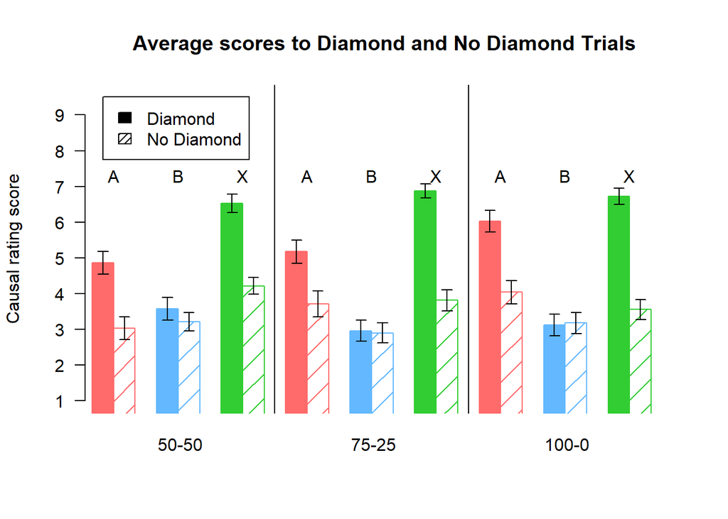

```r
par(mfrow = c(1,1))
par(las = 1)
emptyPlot(c(1,130), c(1,9.5), xaxt = "none", ymark= c(1,2,3,4,5,6, 7, 8,9), bty = 'n', main = "Average scores to Diamond and No Diamond Trials", xlab = "", ylab = "Causal rating score")
add_bars(x=c(0,5,15,20,30,35, 45,50,60,65,75,80, 90,95,105,110,120,125), y=c(DiamondAvg$A[DiamondAvg$Cond == "0"], NoDiamondAvg$A[NoDiamondAvg$Cond == "0"], DiamondAvg$B[DiamondAvg$Cond == "0"], NoDiamondAvg$B[NoDiamondAvg$Cond == "0"],DiamondAvg$X[DiamondAvg$Cond == "0"], NoDiamondAvg$X[NoDiamondAvg$Cond == "0"], DiamondAvg$A[DiamondAvg$Cond == "50"], NoDiamondAvg$A[NoDiamondAvg$Cond == "50"], DiamondAvg$B[DiamondAvg$Cond == "50"], NoDiamondAvg$B[NoDiamondAvg$Cond == "50"],DiamondAvg$X[DiamondAvg$Cond == "50"], NoDiamondAvg$X[NoDiamondAvg$Cond == "50"], DiamondAvg$A[DiamondAvg$Cond == "100"], NoDiamondAvg$A[NoDiamondAvg$Cond == "100"], DiamondAvg$B[DiamondAvg$Cond == "100"], NoDiamondAvg$B[NoDiamondAvg$Cond == "100"],DiamondAvg$X[DiamondAvg$Cond == "100"], NoDiamondAvg$X[NoDiamondAvg$Cond == "100"]), width = 5, col = c("indianred1", "indianred1", "steelblue1", "steelblue1", "limegreen", "limegreen"), density = c(200,6))

errorbars(x=c(0,5,15,20,30,35, 45,50,60,65,75,80, 90,95,105,110,120,125), y=c(DiamondAvg$A[DiamondAvg$Cond == "0"], NoDiamondAvg$A[NoDiamondAvg$Cond == "0"], DiamondAvg$B[DiamondAvg$Cond == "0"], NoDiamondAvg$B[NoDiamondAvg$Cond == "0"],DiamondAvg$X[DiamondAvg$Cond == "0"], NoDiamondAvg$X[NoDiamondAvg$Cond == "0"], DiamondAvg$A[DiamondAvg$Cond == "50"], NoDiamondAvg$A[NoDiamondAvg$Cond == "50"], DiamondAvg$B[DiamondAvg$Cond == "50"], NoDiamondAvg$B[NoDiamondAvg$Cond == "50"],DiamondAvg$X[DiamondAvg$Cond == "50"], NoDiamondAvg$X[NoDiamondAvg$Cond == "50"], DiamondAvg$A[DiamondAvg$Cond == "100"], NoDiamondAvg$A[NoDiamondAvg$Cond == "100"], DiamondAvg$B[DiamondAvg$Cond == "100"], NoDiamondAvg$B[NoDiamondAvg$Cond == "100"],DiamondAvg$X[DiamondAvg$Cond == "100"], NoDiamondAvg$X[NoDiamondAvg$Cond == "100"]) , top = SE , bottom = SE, add = TRUE, length = .05)

abline(v=40, col="grey2", lty = 1)
abline(v=85, col="grey2", lty = 1)
#condition text
mtext("50-50", side = 1, at = 18, line = 1)
mtext("75-25", side = 1, at = 63, line = 1)
mtext("100-0", side = 1, at = 108, line = 1)
#letters
text(x=2.5, y = 7.3, labels = "A")
text(x=47.5, y = 7.3, labels = "A")
text(x=92.5, y = 7.3, labels = "A")
text(x=17.5, y = 7.3, labels = "B")
text(x=62.5, y = 7.3, labels = "B")
text(x=107.5, y = 7.3, labels = "B")
text(x=32.5, y = 7.3, labels = "X")
text(x=77.5, y = 7.3, labels = "X")
text(x=122.5, y = 7.3, labels = "X")
legend(x=0, y = 9.5, legend =c("Diamond", "No Diamond"), density = c(200,20), col= c("indianred1"))
```

```r
#c("indianred1", "indianred3", "steelblue1", "steelblue3", "limegreen", "palegreen4"))

SE
```

```
##  [1] 0.3175977 0.3172144 0.3145093 0.2558443 0.2557916 0.2397742 0.3279081
##  [8] 0.3635234 0.2927941 0.2742077 0.2001988 0.2922098 0.3024033 0.3287124
## [15] 0.3026126 0.2910995 0.2241627 0.2806926
```

```r
range(SE)
```

```
## [1] 0.2001988 0.3635234
```

```r
t.test(Diamond$responseR1[Diamond$Cond == "0"], NoDiamond$responseR1[NoDiamond$Cond == "0"], alternative = "two.sided", paired = FALSE) #sign, diamond higher than not diamond
```

```
##
##  Welch Two Sample t-test
##
## data:  Diamond$responseR1[Diamond$Cond == "0"] and NoDiamond$responseR1[NoDiamond$Cond == "0"]
## t = 4.0935, df = 158, p-value = 6.761e-05
## alternative hypothesis: true difference in means is not equal to 0
## 95 percent confidence interval:
##  0.9509206 2.7240794
## sample estimates:
## mean of x mean of y
##    4.8625    3.0250
```

```r
t.test(Diamond$responseR2[Diamond$Cond == "0"], NoDiamond$responseR2[NoDiamond$Cond == "0"], alternative = "two.sided", paired = FALSE) #not sign
```

```
##
##  Welch Two Sample t-test
##
## data:  Diamond$responseR2[Diamond$Cond == "0"] and NoDiamond$responseR2[NoDiamond$Cond == "0"]
## t = 0.87867, df = 147.1, p-value = 0.381
## alternative hypothesis: true difference in means is not equal to 0
## 95 percent confidence interval:
##  -0.4449784  1.1574558
## sample estimates:
## mean of x mean of y
##  3.571429  3.215190
```

```r
t.test(Diamond$responseR3[Diamond$Cond == "0"], NoDiamond$responseR3[NoDiamond$Cond == "0"], alternative = "two.sided", paired = FALSE) #sign, diamond higher than not diamond
```

```
##
##  Welch Two Sample t-test
##
## data:  Diamond$responseR3[Diamond$Cond == "0"] and NoDiamond$responseR3[NoDiamond$Cond == "0"]
## t = 6.584, df = 151.09, p-value = 7.117e-10
## alternative hypothesis: true difference in means is not equal to 0
## 95 percent confidence interval:
##  1.615653 3.001081
## sample estimates:
## mean of x mean of y
##  6.526316  4.217949
```

```r
t.test(Diamond$responseR1[Diamond$Cond == "50"], NoDiamond$responseR1[NoDiamond$Cond == "50"], alternative = "two.sided", paired = FALSE) #sign, diamond higher than not diamond
```

```
##
##  Welch Two Sample t-test
##
## data:  Diamond$responseR1[Diamond$Cond == "50"] and NoDiamond$responseR1[NoDiamond$Cond == "50"]
## t = 2.9948, df = 155.15, p-value = 0.003198
## alternative hypothesis: true difference in means is not equal to 0
## 95 percent confidence interval:
##  0.4990681 2.4332104
## sample estimates:
## mean of x mean of y
##  5.175000  3.708861
```

```r
t.test(Diamond$responseR2[Diamond$Cond == "50"], NoDiamond$responseR2[NoDiamond$Cond == "50"], alternative = "two.sided", paired = FALSE) #not sign
```

```
##
##  Welch Two Sample t-test
##
## data:  Diamond$responseR2[Diamond$Cond == "50"] and NoDiamond$responseR2[NoDiamond$Cond == "50"]
## t = 0.15341, df = 155.05, p-value = 0.8783
## alternative hypothesis: true difference in means is not equal to 0
## 95 percent confidence interval:
##  -0.7308785  0.8539555
## sample estimates:
## mean of x mean of y
##  2.961538  2.900000
```

```r
t.test(Diamond$responseR3[Diamond$Cond == "50"], NoDiamond$responseR3[NoDiamond$Cond == "50"], alternative = "two.sided", paired = FALSE) #sign, diamond higher than not diamond
```

```
##
##  Welch Two Sample t-test
##
## data:  Diamond$responseR3[Diamond$Cond == "50"] and NoDiamond$responseR3[NoDiamond$Cond == "50"]
## t = 8.6436, df = 137.68, p-value = 1.238e-14
## alternative hypothesis: true difference in means is not equal to 0
## 95 percent confidence interval:
##  2.361269 3.762067
## sample estimates:
## mean of x mean of y
##  6.871795  3.810127
```

```r
t.test(Diamond$responseR1[Diamond$Cond == "100"], NoDiamond$responseR1[NoDiamond$Cond == "100"], alternative = "two.sided", paired = FALSE) #sign, diamond higher than not diamond
```

```
##
##  Welch Two Sample t-test
##
## data:  Diamond$responseR1[Diamond$Cond == "100"] and NoDiamond$responseR1[NoDiamond$Cond == "100"]
## t = 4.4498, df = 156.91, p-value = 1.622e-05
## alternative hypothesis: true difference in means is not equal to 0
## 95 percent confidence interval:
##  1.10527 2.86973
## sample estimates:
## mean of x mean of y
##    6.0250    4.0375
```

```r
t.test(Diamond$responseR2[Diamond$Cond == "100"], NoDiamond$responseR2[NoDiamond$Cond == "100"], alternative = "two.sided", paired = FALSE) #not sign
```

```
##
##  Welch Two Sample t-test
##
## data:  Diamond$responseR2[Diamond$Cond == "100"] and NoDiamond$responseR2[NoDiamond$Cond == "100"]
## t = -0.11908, df = 157.76, p-value = 0.9054
## alternative hypothesis: true difference in means is not equal to 0
## 95 percent confidence interval:
##  -0.8793444  0.7793444
## sample estimates:
## mean of x mean of y
##     3.125     3.175
```

```r
t.test(Diamond$responseR3[Diamond$Cond == "100"], NoDiamond$responseR3[NoDiamond$Cond == "100"], alternative = "two.sided", paired = FALSE) #sign, diamond higher than not diamond
```

```
##
##  Welch Two Sample t-test
##
## data:  Diamond$responseR3[Diamond$Cond == "100"] and NoDiamond$responseR3[NoDiamond$Cond == "100"]
## t = 8.7996, df = 148.17, p-value = 3.279e-15
## alternative hypothesis: true difference in means is not equal to 0
## 95 percent confidence interval:
##  2.451136 3.870838
## sample estimates:
## mean of x mean of y
##  6.717949  3.556962
```

These t-test show exactly what we would expect. The diamond trials are always scored higher than the no diamond trials. That is except for B. This makes sense though, because, B predicts an allergic outcome a lot less than the others. So here we would expect that people will start to score B lower overall, even on the trials where it does predict an allergic reaction. In the original one B in condition 50-50 was signficiantly different, but here it is not.

```r
table(train$CondFirstBlock)
```

```
##
##   0 100  50
## 192  96 192
```

I thought this might be due to the fact that less people saw condition 50-50 as their first block and therefore would have a bias already, but this does not necessarily seem to be the case.

## TEST PHASE

```r
#First getting the test phase data
test <- dat[which(dat$Train_Test == "Test"),]
test$responseR1[test$responseR1 == 999] <- NA
test$responseR2[test$responseR2 == 999] <- NA
test$responseR3[test$responseR3 == 999] <- NA

#And also splitting them into the different phases
testP1 <- test[which(test$Cond == "Phase1"),]
testP2 <- test[which(test$Cond == "Phase2"),]
testP3 <- test[which(test$Cond == "Phase3"),]
```

### Phase 1

This phase was in the same order for each participant. At first the cues from the first block were seen, then a new cue (together with X of the first block) and then those of the third block were seen. This time participants were asked how likely they thought these items would lead to outcome Y, with Y being either a diamond (which they’ve seen before) or a fossil (a new outcome)

```r
#Phase 1

#I want to look at the outcome to fossil and that to diamond
testF <- testP1[which(testP1$Outcome == "Fossil.png"),]
testD <- testP1[which(testP1$Outcome == "Diamond.png"),]

#Now I want the average scores for A B and X for each of these outcomes, but also specifically A1, B1 etc. Therefore I will have to look at specific responses to trials. Therefore aggregate isn't very useful to use here.

#X
X1F <- testF[which(testF$Trial == 2 | testF$Trial == 4 | testF$Trial == 6),]
avgX1F <- mean(X1F$responseR2, na.rm = T)
X1D <- testD[which(testD$Trial == 1 | testD$Trial == 3 | testD$Trial == 5),]
avgX1D <- mean(X1D$responseR2, na.rm = T)
X3F <- testF[which(testF$Trial == 8 | testF$Trial == 10),]
avgX3F <- mean(X3F$responseR2, na.rm = T)
X3D <- testD[which(testD$Trial == 7 | testD$Trial == 9),]
avgX3D <- mean(X3D$responseR2, na.rm = T)

#A
A1F <- testF[which(testF$Trial == 2),]
avgA1F <- mean(A1F$responseR1, na.rm = T)
A1D <- testD[which(testD$Trial == 1),]
avgA1D <- mean(A1D$responseR1, na.rm = T)

A3F <- testF[which(testF$Trial == 8),]
avgA3F <- mean(A3F$responseR1, na.rm = T)
A3D <- testD[which(testD$Trial == 7),]
avgA3D <- mean(A3D$responseR1, na.rm = T)

#B
B1F <- testF[which(testF$Trial == 4),]
avgB1F <- mean(B1F$responseR1, na.rm = T)
B1D <- testD[which(testD$Trial == 3),]
avgB1D <- mean(B1D$responseR1, na.rm = T)

B3F <- testF[which(testF$Trial == 10),]
avgB3F <- mean(B3F$responseR1, na.rm = T)
B3D <- testD[which(testD$Trial == 9),]
avgB3D <- mean(B3D$responseR1, na.rm = T)

#C
CF <- testF[which(testF$Trial == 6),]
avgCF <- mean(CF$responseR1, na.rm = T)
CD <- testD[which(testD$Trial == 5),]
avgCD <- mean(CD$responseR1, na.rm = T)


Cue <- c("A1", "B1", "X1", "C", "A3", "B3", "X3")
Diamond <- c(avgA1D, avgB1D, avgX1D, avgCD, avgA3D, avgB3D, avgX3D)
Fossil <- c(avgA1F, avgB1F, avgX1F, avgCF, avgA3F, avgB3F, avgX3F)
Phase1 <- data.frame(Cue, Diamond, Fossil)
Phase1
```

```
##   Cue  Diamond   Fossil
## 1  A1 4.000000 2.300000
## 2  B1 4.600000 2.300000
## 3  X1 6.666667 2.633333
## 4   C 2.000000 3.300000
## 5  A3 7.000000 2.800000
## 6  B3 3.500000 3.400000
## 7  X3 6.100000 3.894737
```

So there are some differences between scoring to diamond (seems a lot higher, expect for C and B3) and Fossil. The thing here is though that these are all categories collapsed. Later we will split those categories and see what happens then.  
Now I’ll get the scores over the entire block.

```r
#now that we know what was asked when in the training phase

ABl1 <- mean(train$responseR1[train$blockNr == "Block1" & train$Trial == 16], na.rm = T)
BBl1 <- mean(train$responseR2[train$blockNr == "Block1" & train$Trial == 16], na.rm = T)
XBl1 <- mean(train$responseR3[train$blockNr == "Block1" & train$Trial == 16], na.rm = T)

ABl3 <- mean(train$responseR1[train$blockNr == "Block3" & train$Trial == 16], na.rm = T)
BBl3 <- mean(train$responseR2[train$blockNr == "Block3" & train$Trial == 16], na.rm = T)
XBl3 <- mean(train$responseR3[train$blockNr == "Block3" & train$Trial == 16], na.rm = T)

Cues <- c("A1", "B1", "X1", "A3", "B3", "X3")
Mean <- c(ABl1, BBl1, XBl1, ABl3, BBl3, XBl3)
TrainAvgBl1_3 <- data.frame(Cues, Mean)
TrainAvgBl1_3
```

```
##   Cues Mean
## 1   A1  3.1
## 2   B1  3.4
## 3   X1  3.9
## 4   A3  4.5
## 5   B3  3.2
## 6   X3  5.3
```

```r
Original <- c(ABl1, BBl1, XBl1, "NA", ABl3, BBl3, XBl3)
Phase1$Original <- as.numeric(Original)
Phase1
```

```
##   Cue  Diamond   Fossil Original
## 1  A1 4.000000 2.300000      3.1
## 2  B1 4.600000 2.300000      3.4
## 3  X1 6.666667 2.633333      3.9
## 4   C 2.000000 3.300000       NA
## 5  A3 7.000000 2.800000      4.5
## 6  B3 3.500000 3.400000      3.2
## 7  X3 6.100000 3.894737      5.3
```

Here we can see the differences in scores to diamond in the test phase (1), fossil (test phase 1) and the original scores to A, B and X in block 1 and 3. This is averaged over all conditions. We will now perform t-tests to see if there is a difference between these values.

```r
#1) Are there significant differences between A, B and X when asked in their original block 1 and in the test phase
t.test(A1D$responseR1, train$responseR1[train$blockNr == "Block1" & train$Trial == 16], alternative = "two.sided", paired = FALSE) #no sign
```

```
##
##  Welch Two Sample t-test
##
## data:  A1D$responseR1 and train$responseR1[train$blockNr == "Block1" & train$Trial == 16]
## t = 0.71425, df = 14.764, p-value = 0.4862
## alternative hypothesis: true difference in means is not equal to 0
## 95 percent confidence interval:
##  -1.789519  3.589519
## sample estimates:
## mean of x mean of y
##       4.0       3.1
```

```r
t.test(B1D$responseR1, train$responseR2[train$blockNr == "Block1" & train$Trial == 16], alternative = "two.sided", paired = FALSE) #no sign             (DIFF FROM 1)
```

```
##
##  Welch Two Sample t-test
##
## data:  B1D$responseR1 and train$responseR2[train$blockNr == "Block1" & train$Trial == 16]
## t = 1.2362, df = 16.23, p-value = 0.234
## alternative hypothesis: true difference in means is not equal to 0
## 95 percent confidence interval:
##  -0.8553802  3.2553802
## sample estimates:
## mean of x mean of y
##       4.6       3.4
```

```r
t.test(X1D$responseR2, train$responseR3[train$blockNr == "Block1" & train$Trial == 16], alternative = "two.sided", paired = FALSE) #sign diff, increase
```

```
##
##  Welch Two Sample t-test
##
## data:  X1D$responseR2 and train$responseR3[train$blockNr == "Block1" & train$Trial == 16]
## t = 3.5739, df = 10.913, p-value = 0.004419
## alternative hypothesis: true difference in means is not equal to 0
## 95 percent confidence interval:
##  1.061161 4.472173
## sample estimates:
## mean of x mean of y
##  6.666667  3.900000
```

```r
#2) Are there sign differences between A, B and X when asked in block 3 and in the test phase
t.test(A3D$responseR1, train$responseR1[train$blockNr == "Block3" & train$Trial == 16], alternative = "two.sided", paired = FALSE) #no diff (DIFF FROM 1)
```

```
##
##  Welch Two Sample t-test
##
## data:  A3D$responseR1 and train$responseR1[train$blockNr == "Block3" & train$Trial == 16]
## t = 1.8271, df = 13.277, p-value = 0.09024
## alternative hypothesis: true difference in means is not equal to 0
## 95 percent confidence interval:
##  -0.4497602  5.4497602
## sample estimates:
## mean of x mean of y
##       7.0       4.5
```

```r
t.test(B3D$responseR1, train$responseR2[train$blockNr == "Block3" & train$Trial == 16], alternative = "two.sided", paired = FALSE) #no diff
```

```
##
##  Welch Two Sample t-test
##
## data:  B3D$responseR1 and train$responseR2[train$blockNr == "Block3" & train$Trial == 16]
## t = 0.28166, df = 17.625, p-value = 0.7815
## alternative hypothesis: true difference in means is not equal to 0
## 95 percent confidence interval:
##  -1.941119  2.541119
## sample estimates:
## mean of x mean of y
##       3.5       3.2
```

```r
t.test(X3D$responseR2, train$responseR3[train$blockNr == "Block3" & train$Trial == 16], alternative = "two.sided", paired = FALSE) #no diff
```

```
##
##  Welch Two Sample t-test
##
## data:  X3D$responseR2 and train$responseR3[train$blockNr == "Block3" & train$Trial == 16]
## t = 0.76955, df = 14.82, p-value = 0.4537
## alternative hypothesis: true difference in means is not equal to 0
## 95 percent confidence interval:
##  -1.418131  3.018131
## sample estimates:
## mean of x mean of y
##       6.1       5.3
```

```r
#3) Is there a sign difference between the C value and that of A B and X in the test phase
t.test(CD$responseR1, A3D$responseR1, alternative = "two.sided", paired = FALSE) #sign diff C is lower
```

```
##
##  Welch Two Sample t-test
##
## data:  CD$responseR1 and A3D$responseR1
## t = -6.5779, df = 16.443, p-value = 5.546e-06
## alternative hypothesis: true difference in means is not equal to 0
## 95 percent confidence interval:
##  -6.607853 -3.392147
## sample estimates:
## mean of x mean of y
##         2         7
```

```r
t.test(CD$responseR1, B3D$responseR1, alternative = "two.sided", paired = FALSE) #no sign diff
```

```
##
##  Welch Two Sample t-test
##
## data:  CD$responseR1 and B3D$responseR1
## t = -1.627, df = 14.059, p-value = 0.1259
## alternative hypothesis: true difference in means is not equal to 0
## 95 percent confidence interval:
##  -3.4766114  0.4766114
## sample estimates:
## mean of x mean of y
##       2.0       3.5
```

```r
t.test(CD$responseR1, X3D$responseR2, alternative = "two.sided", paired = FALSE) #sign diff, score to C is lower
```

```
##
##  Welch Two Sample t-test
##
## data:  CD$responseR1 and X3D$responseR2
## t = -6.0625, df = 26.377, p-value = 1.975e-06
## alternative hypothesis: true difference in means is not equal to 0
## 95 percent confidence interval:
##  -5.489169 -2.710831
## sample estimates:
## mean of x mean of y
##       2.0       6.1
```

```r
t.test(CD$responseR1, A1D$responseR1, alternative = "two.sided", paired = FALSE) #sign diff, C is lower               (DIFF FROM 1)
```

```
##
##  Welch Two Sample t-test
##
## data:  CD$responseR1 and A1D$responseR1
## t = -2.5355, df = 15.964, p-value = 0.02207
## alternative hypothesis: true difference in means is not equal to 0
## 95 percent confidence interval:
##  -3.6725121 -0.3274879
## sample estimates:
## mean of x mean of y
##         2         4
```

```r
t.test(CD$responseR1, B1D$responseR1, alternative = "two.sided", paired = FALSE) #sign diff, C lower
```

```
##
##  Welch Two Sample t-test
##
## data:  CD$responseR1 and B1D$responseR1
## t = -3.6211, df = 17.139, p-value = 0.002087
## alternative hypothesis: true difference in means is not equal to 0
## 95 percent confidence interval:
##  -4.113959 -1.086041
## sample estimates:
## mean of x mean of y
##       2.0       4.6
```

```r
t.test(CD$responseR1, X1D$responseR2, alternative = "two.sided", paired = FALSE) #sign diff, score to C is lower
```

```
##
##  Welch Two Sample t-test
##
## data:  CD$responseR1 and X1D$responseR2
## t = -9.2244, df = 14.389, p-value = 2.012e-07
## alternative hypothesis: true difference in means is not equal to 0
## 95 percent confidence interval:
##  -5.748976 -3.584358
## sample estimates:
## mean of x mean of y
##  2.000000  6.666667
```

```r
#4) Is there a difference between the ratings to fossil and those to diamond?
t.test(A1D$responseR1, A1F$responseR1, alternative = "two.sided", paired = FALSE) #not sign (marginally, then fossil lower than diamond)
```

```
##
##  Welch Two Sample t-test
##
## data:  A1D$responseR1 and A1F$responseR1
## t = 2.0144, df = 17.4, p-value = 0.05969
## alternative hypothesis: true difference in means is not equal to 0
## 95 percent confidence interval:
##  -0.07742691  3.47742691
## sample estimates:
## mean of x mean of y
##       4.0       2.3
```

```r
t.test(B1D$responseR1, B1F$responseR1, alternative = "two.sided", paired = FALSE) #sign, lower score on the fossil than on the diamond
```

```
##
##  Welch Two Sample t-test
##
## data:  B1D$responseR1 and B1F$responseR1
## t = 3.0114, df = 17.88, p-value = 0.007538
## alternative hypothesis: true difference in means is not equal to 0
## 95 percent confidence interval:
##  0.6946224 3.9053776
## sample estimates:
## mean of x mean of y
##       4.6       2.3
```

```r
t.test(X1D$responseR2, X1F$responseR2, alternative = "two.sided", paired = FALSE) #sign, lower score on the fossil than on the diamond
```

```
##
##  Welch Two Sample t-test
##
## data:  X1D$responseR2 and X1F$responseR2
## t = 8.8763, df = 47.938, p-value = 1.092e-11
## alternative hypothesis: true difference in means is not equal to 0
## 95 percent confidence interval:
##  3.119680 4.946987
## sample estimates:
## mean of x mean of y
##  6.666667  2.633333
```

```r
t.test(CD$responseR1, CF$responseR1, alternative = "two.sided", paired = FALSE)   #no sign (makes sense! The cue is new)
```

```
##
##  Welch Two Sample t-test
##
## data:  CD$responseR1 and CF$responseR1
## t = -1.4137, df = 14.088, p-value = 0.1792
## alternative hypothesis: true difference in means is not equal to 0
## 95 percent confidence interval:
##  -3.2710613  0.6710613
## sample estimates:
## mean of x mean of y
##       2.0       3.3
```

```r
t.test(A3D$responseR1, A3F$responseR1, alternative = "two.sided", paired = FALSE) #sign, lower score on the fossil than on the diamond
```

```
##
##  Welch Two Sample t-test
##
## data:  A3D$responseR1 and A3F$responseR1
## t = 4.3578, df = 17.394, p-value = 0.0004078
## alternative hypothesis: true difference in means is not equal to 0
## 95 percent confidence interval:
##  2.170089 6.229911
## sample estimates:
## mean of x mean of y
##       7.0       2.8
```

```r
t.test(B3D$responseR1, B3F$responseR1, alternative = "two.sided", paired = FALSE) #not sign                                                     (DIFF FROM 1)
```

```
##
##  Welch Two Sample t-test
##
## data:  B3D$responseR1 and B3F$responseR1
## t = 0.087002, df = 17.995, p-value = 0.9316
## alternative hypothesis: true difference in means is not equal to 0
## 95 percent confidence interval:
##  -2.314836  2.514836
## sample estimates:
## mean of x mean of y
##       3.5       3.4
```

```r
t.test(X3D$responseR2, X3F$responseR2, alternative = "two.sided", paired = FALSE) #sign, lower score fossil than on diamond                     (DIFF FROM 1)
```

```
##
##  Welch Two Sample t-test
##
## data:  X3D$responseR2 and X3F$responseR2
## t = 2.714, df = 34.864, p-value = 0.01026
## alternative hypothesis: true difference in means is not equal to 0
## 95 percent confidence interval:
##  0.5554387 3.8550876
## sample estimates:
## mean of x mean of y
##  6.100000  3.894737
```

```r
#OLD###################################################################################################################################
#1) Are there significant differences between A, B and X when asked in their original block 1 and in the test phase
#t.test(A1D$responseR1, train$responseR1[train$blockNr == "Block1"], alternative = "two.sided", paired = FALSE) #no sign
#t.test(B1D$responseR1, train$responseR2[train$blockNr == "Block1"], alternative = "two.sided", paired = FALSE) #no sign             (DIFF FROM 1)
#t.test(X1D$responseR2, train$responseR3[train$blockNr == "Block1"], alternative = "two.sided", paired = FALSE) #sign diff, increase


#2) Are there sign differences between A, B and X when asked in block 3 and in the test phase
#t.test(A3D$responseR1, train$responseR1[train$blockNr == "Block3"], alternative = "two.sided", paired = FALSE) #sign diff, increase
#t.test(B3D$responseR1, train$responseR2[train$blockNr == "Block3"], alternative = "two.sided", paired = FALSE) #no diff
#t.test(X3D$responseR2, train$responseR3[train$blockNr == "Block3"], alternative = "two.sided", paired = FALSE) #no diff

#The only difference in significance is that of B1 in this experiment versus in the older one. In both block 1 and block 2 there is only one response significantly different when looking at the diamond trails vs the original scores. This does not really indicate one model or the other


#3) Is there a sign difference between the C value and that of A B and X in the test phase
#t.test(CD$responseR1, train$responseR1[train$blockNr == "Block3"], alternative = "two.sided", paired = FALSE) #sign diff, score to C is lower
#t.test(CD$responseR1, train$responseR2[train$blockNr == "Block3"], alternative = "two.sided", paired = FALSE) #no sign diff
#t.test(CD$responseR1, train$responseR3[train$blockNr == "Block3"], alternative = "two.sided", paired = FALSE) #sign diff, score to C is lower


#t.test(CD$responseR1, train$responseR1[train$blockNr == "Block1"], alternative = "two.sided", paired = FALSE) #sign diff, score to C is lower
#t.test(CD$responseR1, train$responseR2[train$blockNr == "Block1"], alternative = "two.sided", paired = FALSE) #sign diff, score to C is lower     (DIFF FROM 1)
#t.test(CD$responseR1, train$responseR3[train$blockNr == "Block1"], alternative = "two.sided", paired = FALSE) #sign diff, score to C is lower

#this seems to indicate that the rescorla-wagner model is going on, as most score higher than the neutral cue, while the others are not different.


#4) Is there a difference between the ratings to fossil and those to diamond?
#t.test(A1D$responseR1, A1F$responseR1, alternative = "two.sided", paired = FALSE) #not sign (marginally, then fossil lower than diamond)
#t.test(B1D$responseR1, B1F$responseR1, alternative = "two.sided", paired = FALSE) #sign, lower score on the fossil than on the diamond
#t.test(X1D$responseR2, X1F$responseR2, alternative = "two.sided", paired = FALSE) #sign, lower score on the fossil than on the diamond
#t.test(CD$responseR1, CF$responseR1, alternative = "two.sided", paired = FALSE)   #no sign (makes sense! The cue is new)
#t.test(A3D$responseR1, A3F$responseR1, alternative = "two.sided", paired = FALSE) #sign, lower score on the fossil than on the diamond
#t.test(B3D$responseR1, B3F$responseR1, alternative = "two.sided", paired = FALSE) #not sign                                                     (DIFF FROM 1)
#t.test(X3D$responseR2, X3F$responseR2, alternative = "two.sided", paired = FALSE) #sign, lower score fossil than on diamond                     (DIFF FROM 1)

#okay so for this it seems that especially in the block that was the furthest away, a new outcome is scored much lower than the already seen one. As for a completely new cue there is no difference between a new or an old outcome.
#for cues that were seen more recently it seems that a new outcome has less of an influence in scoring
```

What I now want to do is split this into the seperate conditions

```r
testFSplit <- aggregate(list(testF$responseR1, testF$responseR2), list(testF$CondFirstBlock, testF$CondThirdBlock, testF$Trial), mean, na.rm = T)
colnames(testFSplit) <- c("Cond1", "Cond3", "Trial", "Response1", "Response2")
testDSplit <- aggregate(list(testD$responseR1, testD$responseR2), list(testD$CondFirstBlock, testD$CondThirdBlock, testD$Trial), mean, na.rm = T)
colnames(testDSplit) <- c("Cond1", "Cond3", "Trial", "Response1", "Response2")

#for each item we want the trials that belong to the first or third cue, and then take those purely from one condition

#X000
X1F000 <- testFSplit[which( (testFSplit$Trial == 2 | testFSplit$Trial == 4 | testFSplit$Trial == 6) & testFSplit$Cond1 == "0") ,]
avgX1F000 <- mean(X1F000$Response2, na.rm = T)
X1D000 <- testDSplit[which( (testDSplit$Trial == 1 | testDSplit$Trial == 3 | testDSplit$Trial == 5) & testDSplit$Cond1 == "0") ,]
avgX1D000 <- mean(X1D000$Response2, na.rm = T)

X3F000 <- testFSplit[which( (testFSplit$Trial == 8 | testFSplit$Trial == 10) & testFSplit$Cond3 == "0"),]
avgX3F000 <- mean(X3F000$Response2, na.rm = T)
X3D000 <- testDSplit[which( (testDSplit$Trial == 7 | testDSplit$Trial == 9) & testDSplit$Cond3 == "0"),]
avgX3D000 <- mean(X3D000$Response2, na.rm = T)

#X050
X1F050 <- testFSplit[which( (testFSplit$Trial == 2 | testFSplit$Trial == 4 | testFSplit$Trial == 6) & testFSplit$Cond1 == "50") ,]
avgX1F050 <- mean(X1F050$Response2, na.rm = T)
X1D050 <- testDSplit[which( (testDSplit$Trial == 1 | testDSplit$Trial == 3 | testDSplit$Trial == 5) & testDSplit$Cond1 == "50") ,]
avgX1D050 <- mean(X1D050$Response2, na.rm = T)

X3F050 <- testFSplit[which( (testFSplit$Trial == 8 | testFSplit$Trial == 10) & testFSplit$Cond3 == "50"),]
avgX3F050 <- mean(X3F050$Response2, na.rm = T)
X3D050 <- testDSplit[which( (testDSplit$Trial == 7 | testDSplit$Trial == 9) & testDSplit$Cond3 == "50"),]
avgX3D050 <- mean(X3D050$Response2, na.rm = T)

#X100
X1F100 <- testFSplit[which( (testFSplit$Trial == 2 | testFSplit$Trial == 4 | testFSplit$Trial == 6) & testFSplit$Cond1 == "100") ,]
avgX1F100 <- mean(X1F100$Response2, na.rm = T)
X1D100 <- testDSplit[which( (testDSplit$Trial == 1 | testDSplit$Trial == 3 | testDSplit$Trial == 5) & testDSplit$Cond1 == "100") ,]
avgX1D100 <- mean(X1D100$Response2, na.rm = T)

X3F100 <- testFSplit[which( (testFSplit$Trial == 8 | testFSplit$Trial == 10) & testFSplit$Cond3 == "100"),]
avgX3F100 <- mean(X3F100$Response2, na.rm = T)
X3D100 <- testDSplit[which( (testDSplit$Trial == 7 | testDSplit$Trial == 9) & testDSplit$Cond3 == "100"),]
avgX3D100 <- mean(X3D100$Response2, na.rm = T)

#######################################
#A000
A1F000 <- testFSplit[which( (testFSplit$Trial == 2 ) & testFSplit$Cond1 == "0") ,]
avgA1F000 <- mean(A1F000$Response1, na.rm = T)
A1D000 <- testDSplit[which( (testDSplit$Trial == 1) & testDSplit$Cond1 == "0") ,]
avgA1D000 <- mean(A1D000$Response1, na.rm = T)

A3F000 <- testFSplit[which( (testFSplit$Trial == 8) & testFSplit$Cond3 == "0"),]
avgA3F000 <- mean(A3F000$Response1, na.rm = T)
A3D000 <- testDSplit[which( (testDSplit$Trial == 7) & testDSplit$Cond3 == "0"),]
avgA3D000 <- mean(A3D000$Response1, na.rm = T)

#A050
A1F050 <- testFSplit[which( (testFSplit$Trial == 2) & testFSplit$Cond1 == "50") ,]
avgA1F050 <- mean(A1F050$Response1, na.rm = T)
A1D050 <- testDSplit[which( (testDSplit$Trial == 1) & testDSplit$Cond1 == "50") ,]
avgA1D050 <- mean(A1D050$Response1, na.rm = T)

A3F050 <- testFSplit[which( (testFSplit$Trial == 8) & testFSplit$Cond3 == "50"),]
avgA3F050 <- mean(A3F050$Response1, na.rm = T)
A3D050 <- testDSplit[which( (testDSplit$Trial == 7) & testDSplit$Cond3 == "50"),]
avgA3D050 <- mean(A3D050$Response1, na.rm = T)

#A100
A1F100 <- testFSplit[which( (testFSplit$Trial == 2) & testFSplit$Cond1 == "100") ,]
avgA1F100 <- mean(A1F100$Response1, na.rm = T)
A1D100 <- testDSplit[which( (testDSplit$Trial == 1) & testDSplit$Cond1 == "100") ,]
avgA1D100 <- mean(A1D100$Response1, na.rm = T)

A3F100 <- testFSplit[which( (testFSplit$Trial == 8) & testFSplit$Cond3 == "100"),]
avgA3F100 <- mean(A3F100$Response1, na.rm = T)
A3D100 <- testDSplit[which( (testDSplit$Trial == 7) & testDSplit$Cond3 == "100"),]
avgA3D100 <- mean(A3D100$Response1, na.rm = T)

#######################################

#B000
B1F000 <- testFSplit[which( (testFSplit$Trial == 4) & testFSplit$Cond1 == "0") ,]
avgB1F000 <- mean(B1F000$Response1, na.rm = T)
B1D000 <- testDSplit[which( (testDSplit$Trial == 3) & testDSplit$Cond1 == "0") ,]
avgB1D000 <- mean(B1D000$Response1, na.rm = T)

B3F000 <- testFSplit[which( (testFSplit$Trial == 10) & testFSplit$Cond3 == "0"),]
avgB3F000 <- mean(B3F000$Response1, na.rm = T)
B3D000 <- testDSplit[which( (testDSplit$Trial == 9) & testDSplit$Cond3 == "0"),]
avgB3D000 <- mean(B3D000$Response1, na.rm = T)

#B050
B1F050 <- testFSplit[which( (testFSplit$Trial == 4) & testFSplit$Cond1 == "50") ,]
avgB1F050 <- mean(B1F050$Response1, na.rm = T)
B1D050 <- testDSplit[which( (testDSplit$Trial == 3) & testDSplit$Cond1 == "50") ,]
avgB1D050 <- mean(B1D050$Response1, na.rm = T)

B3F050 <- testFSplit[which( (testFSplit$Trial == 10) & testFSplit$Cond3 == "50"),]
avgB3F050 <- mean(B3F050$Response1, na.rm = T)
B3D050 <- testDSplit[which( (testDSplit$Trial == 9) & testDSplit$Cond3 == "50"),]
avgB3D050 <- mean(B3D050$Response1, na.rm = T)

#B100
B1F100 <- testFSplit[which( (testFSplit$Trial == 4) & testFSplit$Cond1 == "100") ,]
avgB1F100 <- mean(B1F100$Response1, na.rm = T)
B1D100 <- testDSplit[which( (testDSplit$Trial == 3) & testDSplit$Cond1 == "100") ,]
avgB1D100 <- mean(B1D100$Response1, na.rm = T)

B3F100 <- testFSplit[which( (testFSplit$Trial == 10) & testFSplit$Cond3 == "100"),]
avgB3F100 <- mean(B3F100$Response1, na.rm = T)
B3D100 <- testDSplit[which( (testDSplit$Trial == 9) & testDSplit$Cond3 == "100"),]
avgB3D100 <- mean(B3D100$Response1, na.rm = T)


#as C was never asked before we cannot really compare it over conditions
#C
CF <- testF[which(testF$Trial == 6),]
avgCF <- mean(CF$responseR1, na.rm = T)
CD <- testD[which(testD$Trial == 5),]
avgCD <- mean(CD$responseR1, na.rm = T)


Cue <- c("A1","A1","A1", "B1", "B1", "B1", "X1", "X1", "X1", "C", "A3", "A3", "A3", "B3", "B3", "B3", "X3", "X3", "X3")
Cond <- c("0", "50", "100", "0", "50", "100", "0", "50", "100", "NA", "0", "50", "100", "0", "50", "100", "0", "50", "100")
Diamond1 <- c(avgA1D000, avgA1D050, avgA1D100, avgB1D000, avgB1D050, avgB1D100, avgX1D000, avgX1D050, avgX1D100, avgCD, avgA3D000, avgA3D050, avgA3D100, avgB3D000, avgB3D050, avgB3D100, avgX3D000, avgX3D050, avgX3D100)
Fossil1 <- c(avgA1F000, avgA1F050, avgA1F100, avgB1F000, avgB1F050, avgB1F100, avgX1F000, avgX1F050, avgX1F100, avgCF, avgA3F000, avgA3F050, avgA3F100, avgB3F000, avgB3F050, avgB3F100, avgX3F000, avgX3F050, avgX3F100)
Phase1Split <- data.frame(Cue, Cond, Diamond1, Fossil1)
Phase1Split
```

```
##    Cue Cond Diamond1  Fossil1
## 1   A1    0 4.750000 1.500000
## 2   A1   50 3.250000 3.750000
## 3   A1  100 4.000000 1.000000
## 4   B1    0 5.250000 2.500000
## 5   B1   50 4.500000 2.750000
## 6   B1  100 3.500000 1.000000
## 7   X1    0 6.583333 3.166667
## 8   X1   50 6.750000 2.916667
## 9   X1  100 6.666667 1.000000
## 10   C   NA 2.000000 3.300000
## 11  A3    0 7.000000 1.000000
## 12  A3   50 6.250000 3.250000
## 13  A3  100 7.750000 3.250000
## 14  B3    0 2.000000 4.500000
## 15  B3   50 5.250000 2.250000
## 16  B3  100 2.500000 4.000000
## 17  X3    0 7.000000 2.000000
## 18  X3   50 5.500000 3.875000
## 19  X3  100 6.250000 4.875000
```

```r
#and now to add on to that, the original ones

#now that we know what was asked when in the training phase
ABl1000 <- mean(train$responseR1[train$blockNr == "Block1" & train$Cond == "0" & train$Trial == 16], na.rm = T)
ABl1050 <- mean(train$responseR1[train$blockNr == "Block1" & train$Cond == "50"& train$Trial == 16], na.rm = T)
ABl1100 <- mean(train$responseR1[train$blockNr == "Block1" & train$Cond == "100"& train$Trial == 16], na.rm = T)

BBl1000 <- mean(train$responseR2[train$blockNr == "Block1" & train$Cond == "0"& train$Trial == 16], na.rm = T)
BBl1050 <- mean(train$responseR2[train$blockNr == "Block1" & train$Cond == "50"& train$Trial == 16], na.rm = T)
BBl1100 <- mean(train$responseR2[train$blockNr == "Block1" & train$Cond == "100"& train$Trial == 16], na.rm = T)

XBl1000 <- mean(train$responseR3[train$blockNr == "Block1" & train$Cond == "0"& train$Trial == 16], na.rm = T)
XBl1050 <- mean(train$responseR3[train$blockNr == "Block1" & train$Cond == "50"& train$Trial == 16], na.rm = T)
XBl1100 <- mean(train$responseR3[train$blockNr == "Block1" & train$Cond == "100"& train$Trial == 16], na.rm = T)

ABl3000 <- mean(train$responseR1[train$blockNr == "Block3" & train$Cond == "0"& train$Trial == 16], na.rm = T)
ABl3050 <- mean(train$responseR1[train$blockNr == "Block3" & train$Cond == "50"& train$Trial == 16], na.rm = T)
ABl3100 <- mean(train$responseR1[train$blockNr == "Block3" & train$Cond == "100"& train$Trial == 16], na.rm = T)

BBl3000 <- mean(train$responseR2[train$blockNr == "Block3" & train$Cond == "0"& train$Trial == 16], na.rm = T)
BBl3050 <- mean(train$responseR2[train$blockNr == "Block3" & train$Cond == "50"& train$Trial == 16], na.rm = T)
BBl3100 <- mean(train$responseR2[train$blockNr == "Block3" & train$Cond == "100"& train$Trial == 16], na.rm = T)

XBl3000 <- mean(train$responseR3[train$blockNr == "Block3" & train$Cond == "0"& train$Trial == 16], na.rm = T)
XBl3050 <- mean(train$responseR3[train$blockNr == "Block3" & train$Cond == "50"& train$Trial == 16], na.rm = T)
XBl3100 <- mean(train$responseR3[train$blockNr == "Block3" & train$Cond == "100"& train$Trial == 16], na.rm = T)


Original <- c(ABl1000, ABl1050, ABl1100, BBl1000, BBl1050, BBl1100, XBl1000, XBl1050, XBl1100, "NA", ABl3000, ABl3050, ABl3100, BBl3000, BBl3050, BBl3100, XBl3000, XBl3050, XBl3100)
Phase1Split$Original <- as.numeric(Original)
Phase1Split
```

```
##    Cue Cond Diamond1  Fossil1 Original
## 1   A1    0 4.750000 1.500000     4.25
## 2   A1   50 3.250000 3.750000     3.00
## 3   A1  100 4.000000 1.000000     1.00
## 4   B1    0 5.250000 2.500000     4.75
## 5   B1   50 4.500000 2.750000     1.75
## 6   B1  100 3.500000 1.000000     4.00
## 7   X1    0 6.583333 3.166667     5.50
## 8   X1   50 6.750000 2.916667     3.25
## 9   X1  100 6.666667 1.000000     2.00
## 10   C   NA 2.000000 3.300000       NA
## 11  A3    0 7.000000 1.000000     5.00
## 12  A3   50 6.250000 3.250000     4.75
## 13  A3  100 7.750000 3.250000     4.00
## 14  B3    0 2.000000 4.500000     3.50
## 15  B3   50 5.250000 2.250000     2.75
## 16  B3  100 2.500000 4.000000     3.50
## 17  X3    0 7.000000 2.000000     5.50
## 18  X3   50 5.500000 3.875000     4.25
## 19  X3  100 6.250000 4.875000     6.25
```

In this table we now see each cue, which condition they were originally asked in, their scores to diamond in the test phase, their scores to fossil in the test phase, and their score in their original block.

First of all is there even a significan difference between the scores given to the different conditions for diamond?

```r
t.test(A1D000$Response1, A1D050$Response1, alternative = "two.sided", paired = FALSE) #no diff (marginally? Then 00 higher than 50)
```

```
##
##  Welch Two Sample t-test
##
## data:  A1D000$Response1 and A1D050$Response1
## t = 4.2426, df = 2, p-value = 0.05132
## alternative hypothesis: true difference in means is not equal to 0
## 95 percent confidence interval:
##  -0.02121746  3.02121746
## sample estimates:
## mean of x mean of y
##      4.75      3.25
```

```r
#t.test(A1D050$Response1, A1D100$Response1, alternative = "two.sided", paired = FALSE) #NOT ENOUGH OBSERVATIONS
#t.test(A1D100$Response1, A1D000$Response1, alternative = "two.sided", paired = FALSE) #NOT ENOUGH OBSERVATIONS

t.test(B1D000$Response1, B1D050$Response1, alternative = "two.sided", paired = FALSE) #no diff
```

```
##
##  Welch Two Sample t-test
##
## data:  B1D000$Response1 and B1D050$Response1
## t = 0.3254, df = 1.9543, p-value = 0.7764
## alternative hypothesis: true difference in means is not equal to 0
## 95 percent confidence interval:
##  -9.392772 10.892772
## sample estimates:
## mean of x mean of y
##      5.25      4.50
```

```r
#t.test(B1D050$Response1, B1D100$Response1, alternative = "two.sided", paired = FALSE) #NOT ENOUGH OBSERVATIONS
#t.test(B1D100$Response1, B1D000$Response1, alternative = "two.sided", paired = FALSE) #NOT ENOUGH OBSERVATIONS

t.test(X1D000$Response2, X1D050$Response2, alternative = "two.sided", paired = FALSE) #no diff
```

```
##
##  Welch Two Sample t-test
##
## data:  X1D000$Response2 and X1D050$Response2
## t = -0.31159, df = 9.9066, p-value = 0.7618
## alternative hypothesis: true difference in means is not equal to 0
## 95 percent confidence interval:
##  -1.360008  1.026675
## sample estimates:
## mean of x mean of y
##  6.583333  6.750000
```

```r
t.test(X1D050$Response2, X1D100$Response2, alternative = "two.sided", paired = FALSE) #no diff
```

```
##
##  Welch Two Sample t-test
##
## data:  X1D050$Response2 and X1D100$Response2
## t = 0.17001, df = 6.071, p-value = 0.8705
## alternative hypothesis: true difference in means is not equal to 0
## 95 percent confidence interval:
##  -1.112703  1.279370
## sample estimates:
## mean of x mean of y
##  6.750000  6.666667
```

```r
t.test(X1D100$Response2, X1D000$Response2, alternative = "two.sided", paired = FALSE) #no diff
```

```
##
##  Welch Two Sample t-test
##
## data:  X1D100$Response2 and X1D000$Response2
## t = 0.16096, df = 6.4738, p-value = 0.877
## alternative hypothesis: true difference in means is not equal to 0
## 95 percent confidence interval:
##  -1.161393  1.328060
## sample estimates:
## mean of x mean of y
##  6.666667  6.583333
```

So for block one there are no significant differences in the scores between the different conditions. So it seems that for the first block, condition does not have an effect on the test phase. For condition 75-25 and 100-0 there were not enoug observations (1 for 100-0 and 2 for 75-25) to perform a t-test on, this makes sense as there are only 10 participants.

```r
#block 3
#t.test(A3D000$Response1, A3D050$Response1, alternative = "two.sided", paired = FALSE) #NOT ENOUGH OBSERVATIONS
t.test(A3D050$Response1, A3D100$Response1, alternative = "two.sided", paired = FALSE) #no diff
```

```
##
##  Welch Two Sample t-test
##
## data:  A3D050$Response1 and A3D100$Response1
## t = -0.69749, df = 1.8096, p-value = 0.5642
## alternative hypothesis: true difference in means is not equal to 0
## 95 percent confidence interval:
##  -11.751461   8.751461
## sample estimates:
## mean of x mean of y
##      6.25      7.75
```

```r
#t.test(A3D100$Response1, A3D000$Response1, alternative = "two.sided", paired = FALSE) #NOT ENOUGH OBSERVATIONS

#t.test(B3D000$Response1, B3D050$Response1, alternative = "two.sided", paired = FALSE) #NOT ENOUGH OBSERVATIONS
t.test(B3D050$Response1, B3D100$Response1, alternative = "two.sided", paired = FALSE) #no diff
```

```
##
##  Welch Two Sample t-test
##
## data:  B3D050$Response1 and B3D100$Response1
## t = 2.0426, df = 1.312, p-value = 0.2403
## alternative hypothesis: true difference in means is not equal to 0
## 95 percent confidence interval:
##  -7.193166 12.693166
## sample estimates:
## mean of x mean of y
##      5.25      2.50
```

```r
#t.test(B3D100$Response1, B3D000$Response1, alternative = "two.sided", paired = FALSE) #NOT ENOUGH OBSERVATIONS

t.test(X3D000$Response2, X3D050$Response2, alternative = "two.sided", paired = FALSE) #no diff
```

```
##
##  Welch Two Sample t-test
##
## data:  X3D000$Response2 and X3D050$Response2
## t = 1.2081, df = 2.165, p-value = 0.3424
## alternative hypothesis: true difference in means is not equal to 0
## 95 percent confidence interval:
##  -3.47053  6.47053
## sample estimates:
## mean of x mean of y
##       7.0       5.5
```

```r
t.test(X3D050$Response2, X3D100$Response2, alternative = "two.sided", paired = FALSE) #no diff
```

```
##
##  Welch Two Sample t-test
##
## data:  X3D050$Response2 and X3D100$Response2
## t = -0.5447, df = 5.069, p-value = 0.6091
## alternative hypothesis: true difference in means is not equal to 0
## 95 percent confidence interval:
##  -4.27498  2.77498
## sample estimates:
## mean of x mean of y
##      5.50      6.25
```

```r
t.test(X3D100$Response2, X3D000$Response2, alternative = "two.sided", paired = FALSE) #no diff
```

```
##
##  Welch Two Sample t-test
##
## data:  X3D100$Response2 and X3D000$Response2
## t = -0.48881, df = 3.4396, p-value = 0.6545
## alternative hypothesis: true difference in means is not equal to 0
## 95 percent confidence interval:
##  -5.298166  3.798166
## sample estimates:
## mean of x mean of y
##      6.25      7.00
```

There are no signficant differences in the last block either, but here too there is an issue of there not being enough observations for A and B.

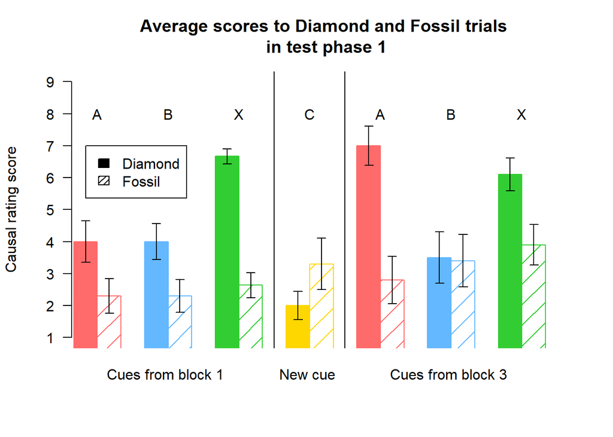

```r
SE_FD <- c(std.error(A1D$responseR1), std.error(A1F$responseR1),std.error(B1D$responseR1), std.error(B1F$responseR1), std.error(X1D$responseR2), std.error(X1F$responseR2), std.error(CD$responseR1), std.error(CF$responseR1), std.error(A3D$responseR1), std.error(A3F$responseR1),std.error(B3D$responseR1), std.error(B3F$responseR1), std.error(X3D$responseR2), std.error(X3F$responseR2))

par(mfrow = c(1,1))
par(las = 1)
emptyPlot(c(1,100), c(1,9), xaxt = "none", ymark= c(1,2,3,4,5,6,7,8,9), bty = 'n', main = "Average scores to Diamond and Fossil trials\n in test phase 1", xlab = "", ylab = "Causal rating score")
add_bars(x=c(0,5,15,20,30,35,45,50,60,65,75,80,90,95), y=c(avgA1D, avgA1F, avgA1D, avgB1F, avgX1D, avgX1F, avgCD, avgCF, avgA3D, avgA3F, avgB3D, avgB3F, avgX3D, avgX3F), width = 5, col = c("indianred1", "indianred1", "steelblue1", "steelblue1", "limegreen", "limegreen","gold", "gold", "indianred1", "indianred1", "steelblue1", "steelblue1", "limegreen", "limegreen"), density = c(200,6))

errorbars(x=c(0,5,15,20,30,35,45,50,60,65,75,80,90,95), y=c(avgA1D, avgA1F, avgA1D, avgB1F, avgX1D, avgX1F, avgCD, avgCF, avgA3D, avgA3F, avgB3D, avgB3F, avgX3D, avgX3F) , top = SE_FD , bottom = SE_FD, add = TRUE, length = .05)

abline(v=40, col="grey2", lty = 1)
abline(v=55, col="grey2", lty = 1)
#condition text
mtext("Cues from block 1", side = 1, at = 17, line = 1)
mtext("New cue", side = 1, at = 47, line = 1)
mtext("Cues from block 3", side = 1, at = 77, line = 1)
#letters
text(x=2.5, y = 8, labels = "A")
text(x=17.5, y = 8, labels = "B")
text(x=32.5, y = 8, labels = "X")
text(x=47.5, y = 8, labels = "C")
text(x=62.5, y = 8, labels = "A")
text(x=77.5, y = 8, labels = "B")
text(x=92.5, y = 8, labels = "X")
legend(x=0, y = 7, legend =c("Diamond", "Fossil"), density = c(200,20))
```

### Phase 2

```r
#Phase 2

#while the trials are in a different order this time around, Trial was a variable given to the _row_ in the table. So in order you will also see that it was "trials 9 then 4 then 8 for example.

#So we basically do the same as before but now I have to rename some things, because I still need stuff like X1F to compare with in a t.test.

testF2 <- testP2[which(testP2$Outcome == "Fossil.png"),]
testD2 <- testP2[which(testP2$Outcome == "Diamond.png"),]

#Now I want the average scores for A B and X for each of these outcomes, but also specifically A1, B1 etc. Therefore I will have to look at specific responses to trials. Therefore aggregate isn't very useful to use here.

#X
X1F2 <- testF2[which(testF2$Trial == 2 | testF2$Trial == 4 | testF2$Trial == 6),]
avgX1F2 <- mean(X1F2$responseR2, na.rm = T)
X1D2 <- testD2[which(testD2$Trial == 1 | testD2$Trial == 3 | testD2$Trial == 5),]
avgX1D2 <- mean(X1D2$responseR2, na.rm = T)
X3F2 <- testF2[which(testF2$Trial == 8 | testF2$Trial == 10),]
avgX3F2 <- mean(X3F2$responseR2, na.rm = T)
X3D2 <- testD2[which(testD2$Trial == 7 | testD2$Trial == 9),]
avgX3D2 <- mean(X3D2$responseR2, na.rm = T)

#A
A1F2 <- testF2[which(testF2$Trial == 2),]
avgA1F2 <- mean(A1F2$responseR1, na.rm = T)
A1D2 <- testD2[which(testD2$Trial == 1),]
avgA1D2 <- mean(A1D2$responseR1, na.rm = T)

A3F2 <- testF2[which(testF2$Trial == 8),]
avgA3F2 <- mean(A3F2$responseR1, na.rm = T)
A3D2 <- testD2[which(testD2$Trial == 7),]
avgA3D2 <- mean(A3D2$responseR1, na.rm = T)

#B
B1F2 <- testF2[which(testF2$Trial == 4),]
avgB1F2 <- mean(B1F2$responseR1, na.rm = T)
B1D2 <- testD2[which(testD2$Trial == 3),]
avgB1D2 <- mean(B1D2$responseR1, na.rm = T)

B3F2 <- testF2[which(testF2$Trial == 10),]
avgB3F2 <- mean(B3F2$responseR1, na.rm = T)
B3D2 <- testD2[which(testD2$Trial == 9),]
avgB3D2 <- mean(B3D2$responseR1, na.rm = T)

#C
CF2 <- testF2[which(testF2$Trial == 6),]
avgCF2 <- mean(CF2$responseR1, na.rm = T)
CD2 <- testD2[which(testD2$Trial == 5),]
avgCD2 <- mean(CD2$responseR1, na.rm = T)


Cue <- c("A1", "B1", "X1", "C", "A3", "B3", "X3")
Diamond2 <- c(avgA1D2, avgB1D2, avgX1D2, avgCD2, avgA3D2, avgB3D2, avgX3D2)
Fossil2 <- c(avgA1F2, avgB1F2, avgX1F2, avgCF2, avgA3F2, avgB3F2, avgX3F2)
Phase2 <- data.frame(Cue, Diamond2, Fossil2)
Phase2
```

```
##   Cue Diamond2 Fossil2
## 1  A1 5.100000    4.00
## 2  B1 5.000000    3.10
## 3  X1 6.666667    3.30
## 4   C 2.500000    2.80
## 5  A3 6.600000    2.80
## 6  B3 3.300000    3.80
## 7  X3 5.900000    3.05
```

```r
Phase1_2 <- data.frame(Cue, Diamond, Fossil, Diamond2, Fossil2)
Phase1_2
```

```
##   Cue  Diamond   Fossil Diamond2 Fossil2
## 1  A1 4.000000 2.300000 5.100000    4.00
## 2  B1 4.600000 2.300000 5.000000    3.10
## 3  X1 6.666667 2.633333 6.666667    3.30
## 4   C 2.000000 3.300000 2.500000    2.80
## 5  A3 7.000000 2.800000 6.600000    2.80
## 6  B3 3.500000 3.400000 3.300000    3.80
## 7  X3 6.100000 3.894737 5.900000    3.05
```

From first glace there do seem to be some differences, especially betwen the fossil socres, but also between some diamond scores. Let’s find out if they are significantly different:

```r
#All no diff, so there is no difference between the scores in Phase 2 and Phase 1 to Diamond
t.test(A1D$responseR1, A1D2$responseR1, alternative = "two.sided", paired = FALSE)
```

```
##
##  Welch Two Sample t-test
##
## data:  A1D$responseR1 and A1D2$responseR1
## t = -1.0493, df = 17.084, p-value = 0.3086
## alternative hypothesis: true difference in means is not equal to 0
## 95 percent confidence interval:
##  -3.310847  1.110847
## sample estimates:
## mean of x mean of y
##       4.0       5.1
```

```r
t.test(B1D$responseR1, B1D2$responseR1, alternative = "two.sided", paired = FALSE)
```

```
##
##  Welch Two Sample t-test
##
## data:  B1D$responseR1 and B1D2$responseR1
## t = -0.44598, df = 17.201, p-value = 0.6612
## alternative hypothesis: true difference in means is not equal to 0
## 95 percent confidence interval:
##  -2.290625  1.490625
## sample estimates:
## mean of x mean of y
##       4.6       5.0
```

```r
t.test(X1D$responseR2, X1D2$responseR2, alternative = "two.sided", paired = FALSE) # this scores is even exactly the same!!
```

```
##
##  Welch Two Sample t-test
##
## data:  X1D$responseR2 and X1D2$responseR2
## t = 0, df = 54.654, p-value = 1
## alternative hypothesis: true difference in means is not equal to 0
## 95 percent confidence interval:
##  -0.7727959  0.7727959
## sample estimates:
## mean of x mean of y
##  6.666667  6.666667
```

```r
t.test(CD$responseR1, CD2$responseR1, alternative = "two.sided", paired = FALSE)
```

```
##
##  Welch Two Sample t-test
##
## data:  CD$responseR1 and CD2$responseR1
## t = -0.66749, df = 16.629, p-value = 0.5136
## alternative hypothesis: true difference in means is not equal to 0
## 95 percent confidence interval:
##  -2.083097  1.083097
## sample estimates:
## mean of x mean of y
##       2.0       2.5
```

```r
t.test(A3D$responseR1, A3D2$responseR1, alternative = "two.sided", paired = FALSE)
```

```
##
##  Welch Two Sample t-test
##
## data:  A3D$responseR1 and A3D2$responseR1
## t = 0.41804, df = 17.467, p-value = 0.681
## alternative hypothesis: true difference in means is not equal to 0
## 95 percent confidence interval:
##  -1.61467  2.41467
## sample estimates:
## mean of x mean of y
##       7.0       6.6
```

```r
t.test(B3D$responseR1, B3D2$responseR1, alternative = "two.sided", paired = FALSE)
```

```
##
##  Welch Two Sample t-test
##
## data:  B3D$responseR1 and B3D2$responseR1
## t = 0.19305, df = 17.232, p-value = 0.8492
## alternative hypothesis: true difference in means is not equal to 0
## 95 percent confidence interval:
##  -1.983572  2.383572
## sample estimates:
## mean of x mean of y
##       3.5       3.3
```

```r
t.test(X3D$responseR2, X3D2$responseR2, alternative = "two.sided", paired = FALSE)
```

```
##
##  Welch Two Sample t-test
##
## data:  X3D$responseR2 and X3D2$responseR2
## t = 0.27458, df = 37.966, p-value = 0.7851
## alternative hypothesis: true difference in means is not equal to 0
## 95 percent confidence interval:
##  -1.274556  1.674556
## sample estimates:
## mean of x mean of y
##       6.1       5.9
```

```r
#all no diff too! So Phase 1 and 2 also don't differ in their scores to Fossil.
t.test(A1F$responseR1, A1F2$responseR1, alternative = "two.sided", paired = FALSE)
```

```
##
##  Welch Two Sample t-test
##
## data:  A1F$responseR1 and A1F2$responseR1
## t = -1.6452, df = 14.892, p-value = 0.1209
## alternative hypothesis: true difference in means is not equal to 0
## 95 percent confidence interval:
##  -3.9038864  0.5038864
## sample estimates:
## mean of x mean of y
##       2.3       4.0
```

```r
t.test(B1F$responseR1, B1F2$responseR1, alternative = "two.sided", paired = FALSE)
```

```
##
##  Welch Two Sample t-test
##
## data:  B1F$responseR1 and B1F2$responseR1
## t = -0.87636, df = 15.962, p-value = 0.3938
## alternative hypothesis: true difference in means is not equal to 0
## 95 percent confidence interval:
##  -2.735576  1.135576
## sample estimates:
## mean of x mean of y
##       2.3       3.1
```

```r
t.test(X1F$responseR2, X1F2$responseR2, alternative = "two.sided", paired = FALSE)
```

```
##
##  Welch Two Sample t-test
##
## data:  X1F$responseR2 and X1F2$responseR2
## t = -1.1218, df = 56.764, p-value = 0.2667
## alternative hypothesis: true difference in means is not equal to 0
## 95 percent confidence interval:
##  -1.8568180  0.5234847
## sample estimates:
## mean of x mean of y
##  2.633333  3.300000
```

```r
t.test(CF$responseR1, CF2$responseR1, alternative = "two.sided", paired = FALSE)
```

```
##
##  Welch Two Sample t-test
##
## data:  CF$responseR1 and CF2$responseR1
## t = 0.4658, df = 17.742, p-value = 0.647
## alternative hypothesis: true difference in means is not equal to 0
## 95 percent confidence interval:
##  -1.757515  2.757515
## sample estimates:
## mean of x mean of y
##       3.3       2.8
```

```r
t.test(A3F$responseR1, A3F2$responseR1, alternative = "two.sided", paired = FALSE) # this one also scores a p-value of 1, meaning exactly the same
```

```
##
##  Welch Two Sample t-test
##
## data:  A3F$responseR1 and A3F2$responseR1
## t = 0, df = 17.942, p-value = 1
## alternative hypothesis: true difference in means is not equal to 0
## 95 percent confidence interval:
##  -2.271945  2.271945
## sample estimates:
## mean of x mean of y
##       2.8       2.8
```

```r
t.test(B3F$responseR1, B3F2$responseR1, alternative = "two.sided", paired = FALSE)
```

```
##
##  Welch Two Sample t-test
##
## data:  B3F$responseR1 and B3F2$responseR1
## t = -0.34933, df = 17.99, p-value = 0.7309
## alternative hypothesis: true difference in means is not equal to 0
## 95 percent confidence interval:
##  -2.805732  2.005732
## sample estimates:
## mean of x mean of y
##       3.4       3.8
```

```r
t.test(X3F$responseR2, X3F2$responseR2, alternative = "two.sided", paired = FALSE)
```

```
##
##  Welch Two Sample t-test
##
## data:  X3F$responseR2 and X3F2$responseR2
## t = 1.0718, df = 33.478, p-value = 0.2915
## alternative hypothesis: true difference in means is not equal to 0
## 95 percent confidence interval:
##  -0.7578991  2.4473728
## sample estimates:
## mean of x mean of y
##  3.894737  3.050000
```

### Phase 3

This phase introduced alternative versions of the stimuli (e.g instead of a mouse now a hamster), and reintroduced the “no diamond” outcome again.

We want to know several things. The first being: what the average scores of the alternatives are and compare those to average of the original blocks?

```r
#Phase 3
testF3 <- testP3[which(testP3$Outcome == "Fossil.png"),]
testD3 <- testP3[which(testP3$Outcome == "Diamond.png"),]
testN3 <- testP3[which(testP3$Outcome == "NoDiamond.png"),]
#We also look at the NoDiamond outcome here, as that one is asked again

#the trial order this time around is different.


#X
X1F3 <- testF3[which(testF3$Trial == 2 | testF3$Trial == 5 | testF3$Trial == 8),]
avgX1F3 <- mean(X1F3$responseR2, na.rm = T)
X1D3 <- testD3[which(testD3$Trial == 1 | testD3$Trial == 4 | testD3$Trial == 7),]
avgX1D3 <- mean(X1D3$responseR2, na.rm = T)
X1N3 <- testN3[which(testN3$Trial == 3 | testN3$Trial == 6 | testN3$Trial == 9),]
avgX1N3 <- mean(X1N3$responseR2, na.rm = T)
X3F3 <- testF3[which(testF3$Trial == 11 | testF3$Trial == 14),]
avgX3F3 <- mean(X3F3$responseR2, na.rm = T)
X3D3 <- testD3[which(testD3$Trial == 10 | testD3$Trial == 13),]
avgX3D3 <- mean(X3D3$responseR2, na.rm = T)
X3N3 <- testN3[which(testN3$Trial == 12 | testN3$Trial == 15),]
avgX3N3 <- mean(X3N3$responseR2, na.rm = T)


#A
A1F3 <- testF3[which(testF3$Trial == 2),]
avgA1F3 <- mean(A1F3$responseR1, na.rm = T)
A1D3 <- testD3[which(testD3$Trial == 1),]
avgA1D3 <- mean(A1D3$responseR1, na.rm = T)
A1N3 <- testN3[which(testN3$Trial == 3),]
avgA1N3 <- mean(A1N3$responseR1, na.rm = T)
A3F3 <- testF3[which(testF3$Trial == 11),]
avgA3F3 <- mean(A3F3$responseR1, na.rm = T)
A3D3 <- testD3[which(testD3$Trial == 10),]
avgA3D3 <- mean(A3D3$responseR1, na.rm = T)
A3N3 <- testN3[which(testN3$Trial == 12),]
avgA3N3 <- mean(A3N3$responseR1, na.rm = T)

#B
B1F3 <- testF3[which(testF3$Trial == 5),]
avgB1F3 <- mean(B1F3$responseR1, na.rm = T)
B1D3 <- testD3[which(testD3$Trial == 4),]
avgB1D3 <- mean(B1D3$responseR1, na.rm = T)
B1N3 <- testN3[which(testN3$Trial == 6),]
avgB1N3 <- mean(B1N3$responseR1, na.rm = T)
B3F3 <- testF3[which(testF3$Trial == 14),]
avgB3F3 <- mean(B3F3$responseR1, na.rm = T)
B3D3 <- testD3[which(testD3$Trial == 13),]
avgB3D3 <- mean(B3D3$responseR1, na.rm = T)
B3N3 <- testN3[which(testN3$Trial == 15),]
avgB3N3 <- mean(B3N3$responseR1, na.rm = T)

#C
CF3 <- testF3[which(testF3$Trial == 8),]
avgCF3 <- mean(CF3$responseR1, na.rm = T)
CD3 <- testD3[which(testD3$Trial == 7),]
avgCD3 <- mean(CD3$responseR1, na.rm = T)
CN3 <- testN3[which(testN3$Trial == 9),]
avgCN3 <- mean(CN3$responseR1, na.rm = T)

Diamond3 <- c(avgA1D3, avgB1D3, avgX1D3, avgCD3, avgA3D3, avgB3D3, avgX3D3)
Fossil3 <- c(avgA1F3, avgB1F3, avgX1F3, avgCF3, avgA3F3, avgB3F3, avgX3F3)
NoDiamond3 <- c(avgA1N3, avgB1N3, avgX1N3, avgCN3, avgA3N3, avgB3N3, avgX3N3)
Phase3 <- data.frame(Cue, Diamond3, Fossil3, NoDiamond3)

Original <- c(ABl1, BBl1, XBl1, "NA", ABl3, BBl3, XBl3)
Phase3$Original <- as.numeric(Original)
Phase3
```

```
##   Cue Diamond3  Fossil3 NoDiamond3 Original
## 1  A1 3.000000 3.111111       2.90      3.1
## 2  B1 3.200000 3.700000       3.30      3.4
## 3  X1 3.758621 3.655172       3.40      3.9
## 4   C 2.400000 3.700000       2.50       NA
## 5  A3 5.400000 3.500000       3.40      4.5
## 6  B3 3.100000 4.500000       3.30      3.2
## 7  X3 3.750000 3.650000       4.35      5.3
```

```r
#differences to the original stimuli in the training phase
t.test(A1D3$responseR1, train$responseR1[train$blockNr == "Block1" & train$Trial == 16], alternative = "two.sided", paired = FALSE) #no diff
```

```
##
##  Welch Two Sample t-test
##
## data:  A1D3$responseR1 and train$responseR1[train$blockNr == "Block1" & train$Trial == 16]
## t = -0.078273, df = 15.211, p-value = 0.9386
## alternative hypothesis: true difference in means is not equal to 0
## 95 percent confidence interval:
##  -2.819818  2.619818
## sample estimates:
## mean of x mean of y
##       3.0       3.1
```

```r
t.test(B1D3$responseR1, train$responseR2[train$blockNr == "Block1" & train$Trial == 16], alternative = "two.sided", paired = FALSE) #no diff
```

```
##
##  Welch Two Sample t-test
##
## data:  B1D3$responseR1 and train$responseR2[train$blockNr == "Block1" & train$Trial == 16]
## t = -0.1957, df = 17.308, p-value = 0.8471
## alternative hypothesis: true difference in means is not equal to 0
## 95 percent confidence interval:
##  -2.353274  1.953274
## sample estimates:
## mean of x mean of y
##       3.2       3.4
```

```r
t.test(X1D3$responseR2, train$responseR3[train$blockNr == "Block1" & train$Trial == 16], alternative = "two.sided", paired = FALSE) #no diff
```

```
##
##  Welch Two Sample t-test
##
## data:  X1D3$responseR2 and train$responseR3[train$blockNr == "Block1" & train$Trial == 16]
## t = -0.16252, df = 16.635, p-value = 0.8729
## alternative hypothesis: true difference in means is not equal to 0
## 95 percent confidence interval:
##  -1.979837  1.697078
## sample estimates:
## mean of x mean of y
##  3.758621  3.900000
```

```r
t.test(A3D3$responseR1, train$responseR1[train$blockNr == "Block3" & train$Trial == 16], alternative = "two.sided", paired = FALSE) #no diff
```

```
##
##  Welch Two Sample t-test
##
## data:  A3D3$responseR1 and train$responseR1[train$blockNr == "Block3" & train$Trial == 16]
## t = 0.59359, df = 16.512, p-value = 0.5608
## alternative hypothesis: true difference in means is not equal to 0
## 95 percent confidence interval:
##  -2.306131  4.106131
## sample estimates:
## mean of x mean of y
##       5.4       4.5
```

```r
t.test(B3D3$responseR1, train$responseR2[train$blockNr == "Block3"& train$Trial == 16], alternative = "two.sided", paired = FALSE) #no diff
```

```
##
##  Welch Two Sample t-test
##
## data:  B3D3$responseR1 and train$responseR2[train$blockNr == "Block3" & train$Trial == 16]
## t = -0.09759, df = 17.893, p-value = 0.9233
## alternative hypothesis: true difference in means is not equal to 0
## 95 percent confidence interval:
##  -2.253726  2.053726
## sample estimates:
## mean of x mean of y
##       3.1       3.2
```

```r
t.test(X3D3$responseR2, train$responseR3[train$blockNr == "Block3"& train$Trial == 16], alternative = "two.sided", paired = FALSE) #no diff
```

```
##
##  Welch Two Sample t-test
##
## data:  X3D3$responseR2 and train$responseR3[train$blockNr == "Block3" & train$Trial == 16]
## t = -1.5058, df = 14.345, p-value = 0.1538
## alternative hypothesis: true difference in means is not equal to 0
## 95 percent confidence interval:
##  -3.7527197  0.6527197
## sample estimates:
## mean of x mean of y
##      3.75      5.30
```

```r
#There are no significant differences between the scores to diamond in the test phase and the scores given in the original block. It seems as though people did notice the categories.


#what happens if we see if there is a difference to the scores of A, B and X to allergic and those to no allergic?
t.test(A1D3$responseR1, A1N3$responseR1, alternative = "two.sided", paired = FALSE) #no diff
```

```
##
##  Welch Two Sample t-test
##
## data:  A1D3$responseR1 and A1N3$responseR1
## t = 0.10547, df = 17.974, p-value = 0.9172
## alternative hypothesis: true difference in means is not equal to 0
## 95 percent confidence interval:
##  -1.892089  2.092089
## sample estimates:
## mean of x mean of y
##       3.0       2.9
```

```r
t.test(B1D3$responseR1, B1N3$responseR1, alternative = "two.sided", paired = FALSE) #no diff
```

```
##
##  Welch Two Sample t-test
##
## data:  B1D3$responseR1 and B1N3$responseR1
## t = -0.11886, df = 17.432, p-value = 0.9067
## alternative hypothesis: true difference in means is not equal to 0
## 95 percent confidence interval:
##  -1.871634  1.671634
## sample estimates:
## mean of x mean of y
##       3.2       3.3
```

```r
t.test(X1D3$responseR2, X1N3$responseR2, alternative = "two.sided", paired = FALSE) #no diff
```

```
##
##  Welch Two Sample t-test
##
## data:  X1D3$responseR2 and X1N3$responseR2
## t = 0.58505, df = 55.685, p-value = 0.5609
## alternative hypothesis: true difference in means is not equal to 0
## 95 percent confidence interval:
##  -0.869464  1.586705
## sample estimates:
## mean of x mean of y
##  3.758621  3.400000
```

```r
t.test(A3D3$responseR1, A3N3$responseR1, alternative = "two.sided", paired = FALSE) #no diff
```

```
##
##  Welch Two Sample t-test
##
## data:  A3D3$responseR1 and A3N3$responseR1
## t = 1.7408, df = 17.177, p-value = 0.0996
## alternative hypothesis: true difference in means is not equal to 0
## 95 percent confidence interval:
##  -0.4220896  4.4220896
## sample estimates:
## mean of x mean of y
##       5.4       3.4
```

```r
t.test(B3D3$responseR1, B3N3$responseR1, alternative = "two.sided", paired = FALSE) #no diff
```

```
##
##  Welch Two Sample t-test
##
## data:  B3D3$responseR1 and B3N3$responseR1
## t = -0.21347, df = 16.616, p-value = 0.8336
## alternative hypothesis: true difference in means is not equal to 0
## 95 percent confidence interval:
##  -2.180168  1.780168
## sample estimates:
## mean of x mean of y
##       3.1       3.3
```

```r
t.test(X3D3$responseR2, X3N3$responseR2, alternative = "two.sided", paired = FALSE) #no diff
```

```
##
##  Welch Two Sample t-test
##
## data:  X3D3$responseR2 and X3N3$responseR2
## t = -0.89105, df = 37.934, p-value = 0.3785
## alternative hypothesis: true difference in means is not equal to 0
## 95 percent confidence interval:
##  -1.9632353  0.7632353
## sample estimates:
## mean of x mean of y
##      3.75      4.35
```

```r
#No differences here. That might indicate that people just were very not sure, as there isn't a clear higher score for a diamond outcome than a non diamond outcome
```